# Churn Risk Classification Model

Predict which clients are at risk of churning so Nate Kowalski's outreach team can prioritize intervention.

**Approach:**

1. Define target: `IS_CHURNED` from ACCOUNTS (Active vs. Churned)
2. Engineer features from support tickets, utilization, engagement, NPS, contracts, and activities
3. Compare Logistic Regression vs. Random Forest
4. Produce a prioritized list of high-risk active accounts

```python
import pandas as pd
import numpy as np
import matplotlib.pyplot as plt
import seaborn as sns
import snowflake.connector
from sklearn.linear_model import LogisticRegression
from sklearn.ensemble import RandomForestClassifier
from sklearn.model_selection import (
    train_test_split, cross_val_score, GridSearchCV,
    StratifiedKFold
)
from sklearn.preprocessing import StandardScaler
from sklearn.pipeline import Pipeline
from sklearn.metrics import (
    confusion_matrix, ConfusionMatrixDisplay,
    precision_score, recall_score, f1_score, accuracy_score,
    roc_curve, auc
)

pd.set_option('display.max_columns', None)
pd.set_option('display.width', None)
plt.style.use('seaborn-v0_8-whitegrid')
plt.rcParams['figure.figsize'] = (10, 6)
plt.rcParams['font.size'] = 11
```

## Step 1 — Connect to Data Warehouse

```python
# Connection parameters
SNOWFLAKE_ACCOUNT = 'EBUHZHQ-ZIB34844'
SNOWFLAKE_DATABASE = 'VANTAGE_SYSTEMS'
SNOWFLAKE_SCHEMA = 'PUBLIC'
SNOWFLAKE_WAREHOUSE = 'TIM147_WH'
SNOWFLAKE_USER = 'TIM147_STUDENT'
SNOWFLAKE_PASSWORD = 'TIM147Winter2026!'

conn = snowflake.connector.connect(
    user=SNOWFLAKE_USER,
    password=SNOWFLAKE_PASSWORD,
    account=SNOWFLAKE_ACCOUNT,
    warehouse=SNOWFLAKE_WAREHOUSE,
    database=SNOWFLAKE_DATABASE,
    schema=SNOWFLAKE_SCHEMA
)

def run_query(conn, query):
    """Execute a query via cursor and return a DataFrame (avoids pd.read_sql warnings)."""
    cur = conn.cursor()
    cur.execute(query)
    columns = [desc[0] for desc in cur.description]
    data = cur.fetchall()
    return pd.DataFrame(data, columns=columns)

def load_table(conn, table_name, limit=None):
    """Load a table into a DataFrame."""
    query = f"SELECT * FROM {table_name}"
    if limit:
        query += f" LIMIT {limit}"
    return run_query(conn, query)

print(f'Connected to {SNOWFLAKE_DATABASE}.{SNOWFLAKE_SCHEMA}')
```

```
Connected to VANTAGE_SYSTEMS.PUBLIC
```

```python
# Check available tables
cursor = conn.cursor()
cursor.execute("SHOW TABLES")
tables = cursor.fetchall()

inventory = []
for table in tables:
    table_name = table[1]
    cursor.execute(f"SELECT COUNT(*) FROM {table_name}")
    row_count = cursor.fetchone()[0]
    inventory.append({'table': table_name, 'rows': row_count})

table_inventory = pd.DataFrame(inventory).sort_values('rows', ascending=False)
print(f'Found {len(table_inventory)} tables\n')
table_inventory
```

```
Found 28 tables
```

|  | table | rows |
| --- | --- | --- |
| 1 | ACTIVITIES | 300537 |
| 26 | TICKET_COMMENTS | 245482 |
| 24 | SUPPORT_TICKETS | 72349 |
| 27 | TIME_ENTRIES | 71116 |
| 8 | ENGAGEMENT_SCORES | 38057 |
| 23 | SERVICE_UTILIZATION | 30003 |
| 19 | ORDER_LINE_ITEMS | 7447 |
| 15 | OPPORTUNITIES | 5056 |
| 16 | OPPORTUNITY_LINE_ITEMS | 5039 |
| 14 | NPS_SURVEYS | 4970 |
| 18 | ORDERS | 3717 |
| 12 | INVOICES | 3717 |
| 20 | PAYMENTS | 3453 |
| 6 | CONTRACT_LINE_ITEMS | 3304 |
| 4 | CONTACTS | 2655 |
| 13 | LEADS | 2277 |
| 3 | CAMPAIGN_RESPONSES | 2030 |
| 0 | ACCOUNTS | 800 |
| 22 | PROJECTS | 691 |
| 5 | CONTRACTS | 419 |
| 2 | CAMPAIGNS | 91 |
| 7 | EMPLOYEES | 65 |
| 10 | FISCAL_PERIODS | 44 |
| 21 | PRODUCTS | 13 |
| 17 | OPPORTUNITY_STAGES | 10 |
| 11 | INDUSTRIES | 9 |
| 25 | TEAMS | 6 |
| 9 | ERP_PLATFORMS | 3 |

## Step 2 — Define Target Variable

**Target:** `IS_CHURNED` (boolean) from the ACCOUNTS table.

**Population:** Accounts with `STATUS IN ('Active', 'Churned')` — excludes Prospects who never had a contract.

```python
# Load accounts and define target population
accounts = load_table(conn, 'ACCOUNTS')

# Check actual STATUS values (Snowflake may return different casing)
print("Actual STATUS values:", accounts['STATUS'].unique())

# Filter to Active and Churned only (exclude Prospects) — case-insensitive
accounts = accounts[accounts['STATUS'].str.lower().isin(['active', 'churned'])].copy()

# Ensure IS_CHURNED is binary (1 = churned, 0 = active)
accounts['IS_CHURNED'] = accounts['IS_CHURNED'].astype(int)

print(f"Total accounts (Active + Churned): {len(accounts)}")
print(f"\nTarget distribution:")
print(accounts['IS_CHURNED'].value_counts())
print(f"\nChurn rate: {accounts['IS_CHURNED'].mean()*100:.1f}%")

print(f"\nSegment breakdown:")
print(accounts.groupby('SEGMENT')['IS_CHURNED'].agg(['count', 'mean']).rename(
    columns={'count': 'n_accounts', 'mean': 'churn_rate'}).round(3))
```

```
Actual STATUS values: ['implementation_only' 'churned' 'lost' 'active' 'prospect']
Total accounts (Active + Churned): 558

Target distribution:
IS_CHURNED
0    430
1    128
Name: count, dtype: int64

Churn rate: 22.9%

Segment breakdown:
           n_accounts  churn_rate
SEGMENT
Core              222       0.189
Growth            177       0.237
SMB                87       0.391
Strategic          72       0.139
```

## Step 3 — Feature Engineering

Build one row per account with features from multiple tables using `aggregate_by_account()`, `compute_trend()`, and `recent_vs_historical()` from the feature_engineering toolkit.

```python
# --- Reusable helper from feature_engineering notebook ---

def aggregate_by_account(conn, table, metrics, date_col=None, cutoff_date=None):
    """Aggregate a table to one row per account."""
    select_parts = ['ACCOUNT_ID'] + [
        f"{expr} AS {name}" for name, expr in metrics.items()
    ]
    query = f"SELECT {', '.join(select_parts)} FROM {table}"
    if date_col and cutoff_date:
        query += f" WHERE {date_col} <= '{cutoff_date}'"
    query += " GROUP BY ACCOUNT_ID"
    df = run_query(conn, query)
    print(f"{table}: {len(df)} accounts, {len(metrics)} metrics")
    return df
```

### 3a — Account Profile Features

```python
# Account-level features from the ACCOUNTS table directly
base = accounts[['ACCOUNT_ID', 'ACCOUNT_NAME', 'SEGMENT', 'INDUSTRY_ID',
                  'EMPLOYEE_COUNT', 'ANNUAL_REVENUE', 'CREATED_DATE',
                  'STATUS', 'IS_CHURNED']].copy()

# Account age in days
base['CREATED_DATE'] = pd.to_datetime(base['CREATED_DATE'])
base['ACCOUNT_AGE_DAYS'] = (pd.Timestamp.now() - base['CREATED_DATE']).dt.days

print(f"Base table: {len(base)} accounts")
base.head()
```

```
Base table: 558 accounts
```

|  | ACCOUNT_ID | ACCOUNT_NAME | SEGMENT | INDUSTRY_ID | EMPLOYEE_COUNT | ANNUAL_REVENUE | CREATED_DATE | STATUS | IS_CHURNED | ACCOUNT_AGE_DAYS |
| --- | --- | --- | --- | --- | --- | --- | --- | --- | --- | --- |
| 2 | 3 | Wilson Components | Growth | 1 | 78.0 | NaN | 2016-09-25 | churned | 1 | 3443 |
| 3 | 4 | American Indianapolis | Growth | 7 | 63.0 | 1.000000e+07 | 2025-11-04 | churned | 1 | 116 |
| 6 | 7 | Lee Group | Core | 6 | 307.0 | 3.871870e+07 | 2018-10-04 | active | 0 | 2704 |
| 9 | 10 | Atlantic Industries Co. | Core | 2 | 193.0 | 2.500000e+07 | 2019-05-15 | active | 0 | 2481 |
| 10 | 11 | OAKLAND EQUIPMENT LTD. | Growth | 2 | NaN | 1.000000e+07 | 2016-06-06 | active | 0 | 3554 |

### 3b — Contract Features

```python
# Contract features aggregated per account
contract_features = aggregate_by_account(conn, 'CONTRACTS', {
    'CONTRACT_COUNT': 'COUNT(*)',
    'AVG_TERM_MONTHS': 'AVG(TERM_MONTHS)',
    'TOTAL_ACV': 'SUM(ANNUAL_VALUE)',
    'AVG_ACV': 'AVG(ANNUAL_VALUE)',
    'AUTO_RENEW_PCT': "AVG(CASE WHEN AUTO_RENEW = TRUE THEN 1 ELSE 0 END)",
    'CANCELLED_CONTRACT_COUNT': "SUM(CASE WHEN STATUS = 'Cancelled' THEN 1 ELSE 0 END)",
    'ACTIVE_CONTRACT_COUNT': "SUM(CASE WHEN STATUS = 'Active' THEN 1 ELSE 0 END)"
})
contract_features.head()
```

```
CONTRACTS: 419 accounts, 7 metrics
```

|  | ACCOUNT_ID | CONTRACT_COUNT | AVG_TERM_MONTHS | TOTAL_ACV | AVG_ACV | AUTO_RENEW_PCT | CANCELLED_CONTRACT_COUNT | ACTIVE_CONTRACT_COUNT |
| --- | --- | --- | --- | --- | --- | --- | --- | --- |
| 0 | 3 | 1 | 36.000000 | 25500.0 | 25500.0 | 1.000000 | 0 | 0 |
| 1 | 4 | 1 | 12.000000 | 30600.0 | 30600.0 | 1.000000 | 0 | 1 |
| 2 | 7 | 1 | 12.000000 | 586080.0 | 586080.0 | 1.000000 | 0 | 1 |
| 3 | 10 | 1 | 24.000000 | 341760.0 | 341760.0 | 1.000000 | 0 | 1 |
| 4 | 11 | 1 | 12.000000 | 311508.0 | 311508.0 | 1.000000 | 0 | 1 |

### 3c — Support Ticket Features

```python
# Support ticket features aggregated per account
ticket_features = aggregate_by_account(conn, 'SUPPORT_TICKETS', {
    'TICKET_COUNT': 'COUNT(*)',
    'HIGH_PRIORITY_PCT': "AVG(CASE WHEN PRIORITY IN ('Critical','High') THEN 1 ELSE 0 END)",
    'AVG_RESOLUTION_HRS': 'AVG(RESOLUTION_HOURS)',
    'AVG_SATISFACTION': 'AVG(SATISFACTION_SCORE)',
    'OPEN_TICKET_COUNT': "SUM(CASE WHEN STATUS NOT IN ('Resolved','Closed') THEN 1 ELSE 0 END)"
})
ticket_features.head()
```

```
SUPPORT_TICKETS: 553 accounts, 5 metrics
```

|  | ACCOUNT_ID | TICKET_COUNT | HIGH_PRIORITY_PCT | AVG_RESOLUTION_HRS | AVG_SATISFACTION | OPEN_TICKET_COUNT |
| --- | --- | --- | --- | --- | --- | --- |
| 0 | 3 | 29 | 0.724138 | 16.408000 | 2.631579 | 4 |
| 1 | 7 | 127 | 0.267717 | 34.049573 | 2.787879 | 10 |
| 2 | 10 | 125 | 0.328000 | 30.427500 | 3.171717 | 5 |
| 3 | 11 | 156 | 0.403846 | 28.441781 | 2.952381 | 10 |
| 4 | 12 | 559 | 0.327370 | 30.824953 | 2.924107 | 22 |

### 3d — Service Utilization Features

```python
# Service utilization — average and trend
util_features = aggregate_by_account(conn, 'SERVICE_UTILIZATION', {
    'AVG_UTILIZATION_PCT': 'AVG(UTILIZATION_PERCENT)',
    'AVG_HOURS_USED': 'AVG(HOURS_USED)',
    'UTIL_MONTHS': 'COUNT(*)'
})

# Compute utilization trend (slope over time) per account
util_raw = load_table(conn, 'SERVICE_UTILIZATION')

def compute_trend(df, account_col, date_col, value_col):
    """Compute trend (slope) of a metric over time per account."""
    df = df.copy()
    df[date_col] = pd.to_datetime(df[date_col])
    trend_col = f"{value_col}_TREND"
    results = []
    for account, group in df.groupby(account_col):
        y = group[value_col].values
        mask = ~np.isnan(y)
        if mask.sum() < 2:
            results.append({account_col: account, trend_col: np.nan})
            continue
        x = (group[date_col] - group[date_col].min()).dt.days.values
        slope = np.polyfit(x[mask], y[mask], 1)[0]
        results.append({account_col: account, trend_col: slope})
    result_df = pd.DataFrame(results)
    valid = result_df[trend_col].notna()
    print(f"Trends for {value_col}: {valid.sum()} accounts")
    return result_df

util_trend = compute_trend(util_raw, 'ACCOUNT_ID', 'PERIOD_MONTH', 'UTILIZATION_PERCENT')

# Recent vs historical utilization
def recent_vs_historical(df, account_col, date_col, value_col, recency_months=6):
    """Compare recent values to historical average per account."""
    df = df.copy()
    df[date_col] = pd.to_datetime(df[date_col])
    cutoff = df[date_col].max() - pd.DateOffset(months=recency_months)
    recent = df[df[date_col] >= cutoff].groupby(account_col)[value_col].mean()
    historical = df[df[date_col] < cutoff].groupby(account_col)[value_col].mean()
    recent_col = f"{value_col}_RECENT"
    ratio_col = f"{value_col}_RATIO"
    result = pd.DataFrame({recent_col: recent})
    result[ratio_col] = recent / historical
    result = result.reset_index()
    print(f"Recent vs historical ({recency_months}mo): {len(result)} accounts")
    return result

util_recent = recent_vs_historical(util_raw, 'ACCOUNT_ID', 'PERIOD_MONTH', 'UTILIZATION_PERCENT')

util_features.head()
```

```
SERVICE_UTILIZATION: 417 accounts, 3 metrics
Trends for UTILIZATION_PERCENT: 415 accounts
Recent vs historical (6mo): 336 accounts
```

|  | ACCOUNT_ID | AVG_UTILIZATION_PCT | AVG_HOURS_USED | UTIL_MONTHS |
| --- | --- | --- | --- | --- |
| 0 | 3 | 0.571049 | 5.709756 | 41 |
| 1 | 7 | 0.696942 | 223.016279 | 86 |
| 2 | 11 | 0.582133 | 116.422124 | 113 |
| 3 | 13 | 0.691667 | 76.081746 | 126 |
| 4 | 14 | 0.617639 | 74.116667 | 72 |

### 3e — Engagement Score Features

```python
# Engagement scores — averages across all monthly periods
engagement_features = aggregate_by_account(conn, 'ENGAGEMENT_SCORES', {
    'AVG_ENGAGEMENT': 'AVG(OVERALL_ENGAGEMENT_SCORE)',
    'AVG_LOGIN_FREQ': 'AVG(LOGIN_FREQUENCY_SCORE)',
    'AVG_FEATURE_ADOPTION': 'AVG(FEATURE_ADOPTION_SCORE)',
    'AVG_SUPPORT_ENGAGEMENT': 'AVG(SUPPORT_ENGAGEMENT_SCORE)',
    'AVG_TRAINING_COMPLETION': 'AVG(TRAINING_COMPLETION_SCORE)'
})

# Engagement trend
eng_raw = load_table(conn, 'ENGAGEMENT_SCORES')
eng_trend = compute_trend(eng_raw, 'ACCOUNT_ID', 'PERIOD_DATE', 'OVERALL_ENGAGEMENT_SCORE')

# Recent vs historical engagement
eng_recent = recent_vs_historical(eng_raw, 'ACCOUNT_ID', 'PERIOD_DATE', 'OVERALL_ENGAGEMENT_SCORE')

engagement_features.head()
```

```
ENGAGEMENT_SCORES: 555 accounts, 5 metrics
Trends for OVERALL_ENGAGEMENT_SCORE: 551 accounts
Recent vs historical (6mo): 454 accounts
```

|  | ACCOUNT_ID | AVG_ENGAGEMENT | AVG_LOGIN_FREQ | AVG_FEATURE_ADOPTION | AVG_SUPPORT_ENGAGEMENT | AVG_TRAINING_COMPLETION |
| --- | --- | --- | --- | --- | --- | --- |
| 0 | 15 | 43.618421 | 45.065789 | 46.197368 | 47.539474 | 35.986842 |
| 1 | 18 | 43.024390 | 44.487805 | 42.073171 | 49.682927 | 37.926829 |
| 2 | 52 | 45.400000 | 45.400000 | 49.133333 | 50.666667 | 37.066667 |
| 3 | 70 | 64.052632 | 66.631579 | 64.473684 | 69.359649 | 56.421053 |
| 4 | 74 | 53.402985 | 54.477612 | 53.000000 | 57.865672 | 50.119403 |

### 3f — NPS Survey Features

```python
# NPS survey features
nps_features = aggregate_by_account(conn, 'NPS_SURVEYS', {
    'AVG_NPS_SCORE': 'AVG(SCORE)',
    'NPS_SURVEY_COUNT': 'COUNT(*)',
    'NPS_RESPONSE_RATE': 'AVG(CASE WHEN RESPONSE_DATE IS NOT NULL THEN 1 ELSE 0 END)',
    'LATEST_NPS': 'MAX(SCORE)',
    'NPS_DETRACTOR_PCT': "AVG(CASE WHEN SCORE <= 6 THEN 1 ELSE 0 END)"
})
nps_features.head()
```

```
NPS_SURVEYS: 531 accounts, 5 metrics
```

|  | ACCOUNT_ID | AVG_NPS_SCORE | NPS_SURVEY_COUNT | NPS_RESPONSE_RATE | LATEST_NPS | NPS_DETRACTOR_PCT |
| --- | --- | --- | --- | --- | --- | --- |
| 0 | 14 | 7.000000 | 8 | 1.000000 | 10 | 0.625000 |
| 1 | 17 | 6.200000 | 5 | 1.000000 | 8 | 0.600000 |
| 2 | 26 | 6.250000 | 20 | 0.950000 | 10 | 0.400000 |
| 3 | 43 | 7.882353 | 17 | 1.000000 | 10 | 0.294118 |
| 4 | 67 | 6.142857 | 7 | 1.000000 | 9 | 0.571429 |

### 3g — Activity (CS Touchpoint) Features

```python
# CS activity features
activity_features = aggregate_by_account(conn, 'ACTIVITIES', {
    'ACTIVITY_COUNT': 'COUNT(*)',
    'NEGATIVE_OUTCOME_PCT': "AVG(CASE WHEN OUTCOME = 'Negative' THEN 1 ELSE 0 END)",
    'POSITIVE_OUTCOME_PCT': "AVG(CASE WHEN OUTCOME = 'Positive' THEN 1 ELSE 0 END)",
    'AVG_ACTIVITY_DURATION': 'AVG(DURATION_MINUTES)',
    'MEETING_COUNT': "SUM(CASE WHEN ACTIVITY_TYPE = 'Meeting' THEN 1 ELSE 0 END)"
})

# Days since last activity per account
activity_recency = run_query(conn, """
    SELECT ACCOUNT_ID,
           DATEDIFF('day', MAX(ACTIVITY_DATE), CURRENT_DATE()) AS DAYS_SINCE_LAST_ACTIVITY
    FROM ACTIVITIES
    GROUP BY ACCOUNT_ID
""")
print(f"Activity recency: {len(activity_recency)} accounts")

activity_features = activity_features.merge(activity_recency, on='ACCOUNT_ID', how='left')
activity_features.head()
```

```
ACTIVITIES: 799 accounts, 5 metrics
Activity recency: 799 accounts
```

|  | ACCOUNT_ID | ACTIVITY_COUNT | NEGATIVE_OUTCOME_PCT | POSITIVE_OUTCOME_PCT | AVG_ACTIVITY_DURATION | MEETING_COUNT | DAYS_SINCE_LAST_ACTIVITY |
| --- | --- | --- | --- | --- | --- | --- | --- |
| 0 | 11 | 362 | 0.000000 | 0.000000 | 37.577348 | 58 | 74 |
| 1 | 20 | 94 | 0.000000 | 0.000000 | 40.361702 | 21 | 1035 |
| 2 | 22 | 6 | 0.000000 | 0.000000 | 51.000000 | 0 | 106 |
| 3 | 48 | 20 | 0.000000 | 0.000000 | 33.450000 | 3 | 75 |
| 4 | 64 | 299 | 0.000000 | 0.000000 | 43.628763 | 52 | 60 |

### 3h — Invoice / Payment Health Features

```python
# Invoice health features
invoice_features = aggregate_by_account(conn, 'INVOICES', {
    'INVOICE_COUNT': 'COUNT(*)',
    'OVERDUE_INVOICE_COUNT': "SUM(CASE WHEN STATUS = 'Overdue' THEN 1 ELSE 0 END)",
    'OVERDUE_INVOICE_PCT': "AVG(CASE WHEN STATUS = 'Overdue' THEN 1 ELSE 0 END)",
    'TOTAL_INVOICED': 'SUM(AMOUNT)'
})
invoice_features.head()
```

```
INVOICES: 691 accounts, 4 metrics
```

|  | ACCOUNT_ID | INVOICE_COUNT | OVERDUE_INVOICE_COUNT | OVERDUE_INVOICE_PCT | TOTAL_INVOICED |
| --- | --- | --- | --- | --- | --- |
| 0 | 1 | 1 | 0 | 0.000000 | 195625.90 |
| 1 | 2 | 2 | 0 | 0.000000 | 193137.12 |
| 2 | 3 | 4 | 0 | 0.000000 | 160133.26 |
| 3 | 4 | 3 | 0 | 0.000000 | 178693.47 |
| 4 | 7 | 11 | 0 | 0.000000 | 817330.91 |

### 3i — Assemble Feature Matrix

```python
# Merge all feature DataFrames into one matrix (build_feature_matrix pattern)
feature_dfs = [
    contract_features,
    ticket_features,
    util_features,
    util_trend,
    util_recent,
    engagement_features,
    eng_trend,
    eng_recent,
    nps_features,
    activity_features,
    invoice_features,
]

# Normalize column names to uppercase for consistent merging
features = base.copy()
for i, fdf in enumerate(feature_dfs):
    fdf = fdf.rename(columns={c: c.upper() for c in fdf.columns})
    before = len(features.columns)
    features = features.merge(fdf, on='ACCOUNT_ID', how='left')
    print(f'  Merged df {i+1}: +{len(features.columns) - before} columns')

print(f'\nFeature matrix: {len(features)} rows, {len(features.columns)} columns')

# Show null summary
nulls = features.isnull().mean()
has_nulls = nulls[nulls > 0].sort_values(ascending=False)
if len(has_nulls) > 0:
    print(f'\nColumns with nulls ({len(has_nulls)}):')
    for col in has_nulls.head(10).index:
        print(f'  {col}: {has_nulls[col]*100:.1f}%')

features.head()
```

```
  Merged df 1: +7 columns
  Merged df 2: +5 columns
  Merged df 3: +3 columns
  Merged df 4: +1 columns
  Merged df 5: +2 columns
  Merged df 6: +5 columns
  Merged df 7: +1 columns
  Merged df 8: +2 columns
  Merged df 9: +5 columns
  Merged df 10: +6 columns
  Merged df 11: +4 columns

Feature matrix: 558 rows, 51 columns

Columns with nulls (33):
  UTILIZATION_PERCENT_RATIO: 41.2%
  UTILIZATION_PERCENT_RECENT: 39.8%
  UTILIZATION_PERCENT_TREND: 25.6%
  AVG_HOURS_USED: 25.3%
  UTIL_MONTHS: 25.3%
  AVG_UTILIZATION_PCT: 25.3%
  AUTO_RENEW_PCT: 24.9%
  CANCELLED_CONTRACT_COUNT: 24.9%
  CONTRACT_COUNT: 24.9%
  AVG_TERM_MONTHS: 24.9%
```

|  | ACCOUNT_ID | ACCOUNT_NAME | SEGMENT | INDUSTRY_ID | EMPLOYEE_COUNT | ANNUAL_REVENUE | CREATED_DATE | STATUS | IS_CHURNED | ACCOUNT_AGE_DAYS | CONTRACT_COUNT | AVG_TERM_MONTHS | TOTAL_ACV | AVG_ACV | AUTO_RENEW_PCT | CANCELLED_CONTRACT_COUNT | ACTIVE_CONTRACT_COUNT | TICKET_COUNT | HIGH_PRIORITY_PCT | AVG_RESOLUTION_HRS | AVG_SATISFACTION | OPEN_TICKET_COUNT | AVG_UTILIZATION_PCT | AVG_HOURS_USED | UTIL_MONTHS | UTILIZATION_PERCENT_TREND | UTILIZATION_PERCENT_RECENT | UTILIZATION_PERCENT_RATIO | AVG_ENGAGEMENT | … |
| --- | --- | --- | --- | --- | --- | --- | --- | --- | --- | --- | --- | --- | --- | --- | --- | --- | --- | --- | --- | --- | --- | --- | --- | --- | --- | --- | --- | --- | --- | --- |
| 0 | 3 | Wilson Components | Growth | 1 | 78.0 | NaN | 2016-09-25 | churned | 1 | 3443 | 1.0 | 36.000000 | 25500.0 | 25500.0 | 1.000000 | 0.0 | 0.0 | 29.0 | 0.724138 | 16.408000 | 2.631579 | 4.0 | 0.571049 | 5.709756 | 41.0 | -0.000085 | NaN | NaN | 51.750000 | … |
| 1 | 4 | American Indianapolis | Growth | 7 | 63.0 | 1.000000e+07 | 2025-11-04 | churned | 1 | 116 | 1.0 | 12.000000 | 30600.0 | 30600.0 | 1.000000 | 0.0 | 1.0 | NaN | NaN | NaN | NaN | NaN | NaN | NaN | NaN | NaN | NaN | NaN | NaN | … |
| 2 | 7 | Lee Group | Core | 6 | 307.0 | 3.871870e+07 | 2018-10-04 | active | 0 | 2704 | 1.0 | 12.000000 | 586080.0 | 586080.0 | 1.000000 | 0.0 | 1.0 | 127.0 | 0.267717 | 34.049573 | 2.787879 | 10.0 | 0.696942 | 223.016279 | 86.0 | 0.000002 | 0.669333 | 0.957541 | 63.738095 | … |
| 3 | 10 | Atlantic Industries Co. | Core | 2 | 193.0 | 2.500000e+07 | 2019-05-15 | active | 0 | 2481 | 1.0 | 24.000000 | 341760.0 | 341760.0 | 1.000000 | 0.0 | 1.0 | 125.0 | 0.328000 | 30.427500 | 3.171717 | 5.0 | 0.675145 | 94.511842 | 76.0 | 0.000014 | 0.667833 | 0.988253 | 64.108108 | … |
| 4 | 11 | OAKLAND EQUIPMENT LTD. | Growth | 2 | NaN | 1.000000e+07 | 2016-06-06 | active | 0 | 3554 | 1.0 | 12.000000 | 311508.0 | 311508.0 | 1.000000 | 0.0 | 1.0 | 156.0 | 0.403846 | 28.441781 | 2.952381 | 10.0 | 0.582133 | 116.422124 | 113.0 | -0.000001 | 0.563833 | 0.966861 | 53.807339 | … |

### 3j — Handle Missing Values & Encode Categoricals

```python
# handle_missing: fill NaN in numeric columns with median
def handle_missing(df, strategy='median', exclude_cols=None):
    """Fill missing values in numeric columns."""
    df = df.copy()
    exclude = set(exclude_cols or [])
    numeric_cols = df.select_dtypes(include=[np.number]).columns
    filled = 0
    for col in numeric_cols:
        if col in exclude:
            continue
        n_missing = df[col].isnull().sum()
        if n_missing == 0:
            continue
        if strategy == 'median':
            df[col] = df[col].fillna(df[col].median())
        elif strategy == 'mean':
            df[col] = df[col].fillna(df[col].mean())
        elif strategy == 'zero':
            df[col] = df[col].fillna(0)
        filled += 1
    print(f'Filled {filled} columns using {strategy}')
    return df

features = handle_missing(features, strategy='median',
                          exclude_cols=['IS_CHURNED', 'ACCOUNT_ID'])

# encode_categoricals: one-hot encode SEGMENT
def encode_categoricals(df, columns, drop_first=True):
    """One-hot encode categorical columns."""
    before = len(df.columns)
    df = pd.get_dummies(df, columns=columns, drop_first=drop_first)
    print(f'Encoded {len(columns)} columns: {before} -> {len(df.columns)} features')
    return df

features = encode_categoricals(features, ['SEGMENT'])

print(f'\nFinal feature matrix: {features.shape}')
features.head()
```

```
Filled 22 columns using median
Encoded 1 columns: 51 -> 53 features

Final feature matrix: (558, 53)
```

|  | ACCOUNT_ID | ACCOUNT_NAME | INDUSTRY_ID | EMPLOYEE_COUNT | ANNUAL_REVENUE | CREATED_DATE | STATUS | IS_CHURNED | ACCOUNT_AGE_DAYS | CONTRACT_COUNT | AVG_TERM_MONTHS | TOTAL_ACV | AVG_ACV | AUTO_RENEW_PCT | CANCELLED_CONTRACT_COUNT | ACTIVE_CONTRACT_COUNT | TICKET_COUNT | HIGH_PRIORITY_PCT | AVG_RESOLUTION_HRS | AVG_SATISFACTION | OPEN_TICKET_COUNT | AVG_UTILIZATION_PCT | AVG_HOURS_USED | UTIL_MONTHS | UTILIZATION_PERCENT_TREND | UTILIZATION_PERCENT_RECENT | UTILIZATION_PERCENT_RATIO | AVG_ENGAGEMENT | AVG_LOGIN_FREQ | … |
| --- | --- | --- | --- | --- | --- | --- | --- | --- | --- | --- | --- | --- | --- | --- | --- | --- | --- | --- | --- | --- | --- | --- | --- | --- | --- | --- | --- | --- | --- | --- |
| 0 | 3 | Wilson Components | 1 | 78.0 | 2.500000e+07 | 2016-09-25 | churned | 1 | 3443 | 1.0 | 36.000000 | 25500.0 | 25500.0 | 1.000000 | 0.0 | 0.0 | 29.0 | 0.724138 | 16.408000 | 2.631579 | 4.0 | 0.571049 | 5.709756 | 41.0 | -0.000085 | 0.660500 | 0.988539 | 51.750000 | 51.750000 | … |
| 1 | 4 | American Indianapolis | 7 | 63.0 | 1.000000e+07 | 2025-11-04 | churned | 1 | 116 | 1.0 | 12.000000 | 30600.0 | 30600.0 | 1.000000 | 0.0 | 1.0 | 108.0 | NaN | 31.151908 | 3.003704 | 5.0 | 0.670085 | 64.053608 | 72.0 | -0.000006 | 0.660500 | 0.988539 | NaN | NaN | … |
| 2 | 7 | Lee Group | 6 | 307.0 | 3.871870e+07 | 2018-10-04 | active | 0 | 2704 | 1.0 | 12.000000 | 586080.0 | 586080.0 | 1.000000 | 0.0 | 1.0 | 127.0 | 0.267717 | 34.049573 | 2.787879 | 10.0 | 0.696942 | 223.016279 | 86.0 | 0.000002 | 0.669333 | 0.957541 | 63.738095 | 62.642857 | … |
| 3 | 10 | Atlantic Industries Co. | 2 | 193.0 | 2.500000e+07 | 2019-05-15 | active | 0 | 2481 | 1.0 | 24.000000 | 341760.0 | 341760.0 | 1.000000 | 0.0 | 1.0 | 125.0 | 0.328000 | 30.427500 | 3.171717 | 5.0 | 0.675145 | 94.511842 | 76.0 | 0.000014 | 0.667833 | 0.988253 | 64.108108 | 63.972973 | … |
| 4 | 11 | OAKLAND EQUIPMENT LTD. | 2 | 131.0 | 1.000000e+07 | 2016-06-06 | active | 0 | 3554 | 1.0 | 12.000000 | 311508.0 | 311508.0 | 1.000000 | 0.0 | 1.0 | 156.0 | 0.403846 | 28.441781 | 2.952381 | 10.0 | 0.582133 | 116.422124 | 113.0 | -0.000001 | 0.563833 | 0.966861 | 53.807339 | 54.733945 | … |

## Step 4 — Data Quality & Profiling

Quick quality check on the assembled feature matrix using functions from the quality_checks and profiling notebooks.

```python
# quality_summary from quality_checks notebook
def quality_summary(df, name='Table', pk_col=None):
    """Quick quality summary of a DataFrame."""
    print(f"\n{name}: {len(df):,} rows, {len(df.columns)} columns\n")
    null_cols = df.isna().sum()
    null_cols = null_cols[null_cols > 0]
    print(f"Columns with nulls: {len(null_cols)} of {len(df.columns)}")
    if len(null_cols) > 0:
        worst = null_cols.idxmax()
        print(f"  Highest null rate: {worst} ({null_cols[worst]/len(df)*100:.1f}%)")
    if pk_col:
        nulls_pk = df[pk_col].isna().sum()
        unique_pk = df[pk_col].nunique()
        print(f"\nPK check ({pk_col}): {unique_pk} unique, {nulls_pk} nulls, valid={nulls_pk==0 and unique_pk==len(df)}")
    dup_rows = df.duplicated().sum()
    print(f"\nExact duplicate rows: {dup_rows:,}")

quality_summary(features, name='Churn Feature Matrix', pk_col='ACCOUNT_ID')
```

```
Churn Feature Matrix: 558 rows, 53 columns

Columns with nulls: 11 of 53
  Highest null rate: AVG_TERM_MONTHS (24.9%)

PK check (ACCOUNT_ID): 558 unique, 0 nulls, valid=True

Exact duplicate rows: 0
```

```python
# profile_table from profiling notebook
def profile_table(df, name='Table'):
    """Summary profile of all columns."""
    print(f"\n{name}: {len(df):,} rows, {len(df.columns)} columns")
    print(f"Memory: {df.memory_usage(deep=True).sum() / 1024**2:.1f} MB\n")
    summary = []
    for col in df.columns:
        dtype = df[col].dtype
        non_null = df[col].count()
        null_pct = df[col].isna().mean() * 100
        unique = df[col].nunique()
        sample = str(df[col].dropna().head(3).tolist())[:40]
        summary.append({
            'column': col, 'dtype': str(dtype),
            'non_null': non_null, 'null_pct': f"{null_pct:.1f}%",
            'unique': unique, 'sample': sample
        })
    return pd.DataFrame(summary)

profile_table(features, 'Churn Feature Matrix')
```

```
Churn Feature Matrix: 558 rows, 53 columns
Memory: 1.1 MB
```

|  | column | dtype | non_null | null_pct | unique | sample |
| --- | --- | --- | --- | --- | --- | --- |
| 0 | ACCOUNT_ID | int64 | 558 | 0.0% | 558 | [3, 4, 7] |
| 1 | ACCOUNT_NAME | object | 558 | 0.0% | 532 | ['Wilson Components', 'American Indianap |
| 2 | INDUSTRY_ID | int64 | 558 | 0.0% | 9 | [1, 7, 6] |
| 3 | EMPLOYEE_COUNT | float64 | 558 | 0.0% | 299 | [78.0, 63.0, 307.0] |
| 4 | ANNUAL_REVENUE | float64 | 558 | 0.0% | 163 | [25000000.0, 10000000.0, 38718702.510016 |
| 5 | CREATED_DATE | datetime64[ns] | 558 | 0.0% | 507 | [Timestamp('2016-09-25 00:00:00'), Times |
| 6 | STATUS | object | 558 | 0.0% | 2 | ['churned', 'churned', 'active'] |
| 7 | IS_CHURNED | int64 | 558 | 0.0% | 2 | [1, 1, 0] |
| 8 | ACCOUNT_AGE_DAYS | int64 | 558 | 0.0% | 507 | [3443, 116, 2704] |
| 9 | CONTRACT_COUNT | float64 | 558 | 0.0% | 1 | [1.0, 1.0, 1.0] |
| 10 | AVG_TERM_MONTHS | object | 419 | 24.9% | 3 | [Decimal('36.000000'), Decimal('12.00000 |
| 11 | TOTAL_ACV | float64 | 558 | 0.0% | 162 | [25500.0, 30600.0, 586080.0] |
| 12 | AVG_ACV | float64 | 558 | 0.0% | 162 | [25500.0, 30600.0, 586080.0] |
| 13 | AUTO_RENEW_PCT | object | 419 | 24.9% | 2 | [Decimal('1.000000'), Decimal('1.000000' |
| 14 | CANCELLED_CONTRACT_COUNT | float64 | 558 | 0.0% | 1 | [0.0, 0.0, 0.0] |
| 15 | ACTIVE_CONTRACT_COUNT | float64 | 558 | 0.0% | 2 | [0.0, 1.0, 1.0] |
| 16 | TICKET_COUNT | float64 | 558 | 0.0% | 265 | [29.0, 108.0, 127.0] |
| 17 | HIGH_PRIORITY_PCT | object | 553 | 0.9% | 433 | [Decimal('0.724138'), Decimal('0.267717' |
| 18 | AVG_RESOLUTION_HRS | float64 | 558 | 0.0% | 551 | [16.408, 31.151908396946567, 34.04957264 |
| 19 | AVG_SATISFACTION | float64 | 558 | 0.0% | 456 | [2.6315789473684212, 3.0037037037037035, |
| 20 | OPEN_TICKET_COUNT | float64 | 558 | 0.0% | 29 | [4.0, 5.0, 10.0] |
| 21 | AVG_UTILIZATION_PCT | float64 | 558 | 0.0% | 417 | [0.5710487804878048, 0.6700851063829787, |
| 22 | AVG_HOURS_USED | float64 | 558 | 0.0% | 417 | [5.709756097560976, 64.05360824742267, 2 |
| 23 | UTIL_MONTHS | float64 | 558 | 0.0% | 121 | [41.0, 72.0, 86.0] |
| 24 | UTILIZATION_PERCENT_TREND | float64 | 558 | 0.0% | 415 | [-8.501990984257634e-05, -6.153971010859 |
| 25 | UTILIZATION_PERCENT_RECENT | float64 | 558 | 0.0% | 315 | [0.6605, 0.6605, 0.6693333333333333] |
| 26 | UTILIZATION_PERCENT_RATIO | float64 | 558 | 0.0% | 329 | [0.9885388490407274, 0.9885388490407274, |
| 27 | AVG_ENGAGEMENT | object | 555 | 0.5% | 544 | [Decimal('51.750000'), Decimal('63.73809 |
| 28 | AVG_LOGIN_FREQ | object | 555 | 0.5% | 546 | [Decimal('51.750000'), Decimal('62.64285 |
| 29 | AVG_FEATURE_ADOPTION | object | 555 | 0.5% | 539 | [Decimal('53.350000'), Decimal('67.34523 |
| 30 | AVG_SUPPORT_ENGAGEMENT | object | 555 | 0.5% | 544 | [Decimal('57.675000'), Decimal('67.67857 |
| 31 | AVG_TRAINING_COMPLETION | object | 555 | 0.5% | 546 | [Decimal('45.825000'), Decimal('58.29761 |
| 32 | OVERALL_ENGAGEMENT_SCORE_TREND | float64 | 558 | 0.0% | 551 | [-0.002350009714140271, -0.0003850259484 |
| 33 | OVERALL_ENGAGEMENT_SCORE_RECENT | float64 | 558 | 0.0% | 213 | [60.41666666666667, 60.41666666666667, 6 |
| 34 | OVERALL_ENGAGEMENT_SCORE_RATIO | float64 | 558 | 0.0% | 439 | [0.997867803837953, 0.997867803837953, 1 |
| 35 | AVG_NPS_SCORE | object | 531 | 4.8% | 223 | [Decimal('4.428571'), Decimal('7.615385' |
| 36 | NPS_SURVEY_COUNT | float64 | 558 | 0.0% | 23 | [7.0, 9.0, 13.0] |
| 37 | NPS_RESPONSE_RATE | object | 531 | 4.8% | 22 | [Decimal('1.000000'), Decimal('1.000000' |
| 38 | LATEST_NPS | float64 | 558 | 0.0% | 11 | [7.0, 10.0, 9.0] |
| 39 | NPS_DETRACTOR_PCT | object | 531 | 4.8% | 80 | [Decimal('0.714286'), Decimal('0.230769' |
| 40 | ACTIVITY_COUNT | int64 | 558 | 0.0% | 425 | [269, 3, 423] |
| 41 | NEGATIVE_OUTCOME_PCT | object | 558 | 0.0% | 1 | [Decimal('0.000000'), Decimal('0.000000' |
| 42 | POSITIVE_OUTCOME_PCT | object | 558 | 0.0% | 1 | [Decimal('0.000000'), Decimal('0.000000' |
| 43 | AVG_ACTIVITY_DURATION | object | 558 | 0.0% | 557 | [Decimal('42.747212'), Decimal('25.33333 |
| 44 | MEETING_COUNT | int64 | 558 | 0.0% | 210 | [55, 0, 71] |
| 45 | DAYS_SINCE_LAST_ACTIVITY | int64 | 558 | 0.0% | 154 | [2114, 87, 62] |
| 46 | INVOICE_COUNT | int64 | 558 | 0.0% | 14 | [4, 3, 11] |
| 47 | OVERDUE_INVOICE_COUNT | int64 | 558 | 0.0% | 1 | [0, 0, 0] |
| 48 | OVERDUE_INVOICE_PCT | object | 558 | 0.0% | 1 | [Decimal('0.000000'), Decimal('0.000000' |
| 49 | TOTAL_INVOICED | float64 | 558 | 0.0% | 558 | [160133.26, 178693.47, 817330.91] |
| 50 | SEGMENT_Growth | bool | 558 | 0.0% | 2 | [True, True, False] |
| 51 | SEGMENT_SMB | bool | 558 | 0.0% | 2 | [False, False, False] |
| 52 | SEGMENT_Strategic | bool | 558 | 0.0% | 2 | [False, False, False] |

```python
# Class balance check — important for classification
print("Target distribution (IS_CHURNED):")
print(features['IS_CHURNED'].value_counts())
print(f"\nChurn rate: {features['IS_CHURNED'].mean()*100:.1f}%")
print(f"Class ratio (active:churned): {(1-features['IS_CHURNED'].mean())/features['IS_CHURNED'].mean():.1f}:1")

# If severely imbalanced, we'll use class_weight='balanced' in modeling
```

```
Target distribution (IS_CHURNED):
IS_CHURNED
0    430
1    128
Name: count, dtype: int64

Churn rate: 22.9%
Class ratio (active:churned): 3.4:1
```

## Step 5 — Exploratory Visualization

Key charts using functions from the visualization notebook.

```python
# --- Visualization helpers from visualization notebook ---

def plot_rate_by_segment(df, segment_col, flag_col, title=None):
    """Plot a rate (e.g., churn rate) by segment."""
    rates = df.groupby(segment_col)[flag_col].mean() * 100
    rates = rates.sort_values(ascending=True)
    fig, ax = plt.subplots(figsize=(10, max(5, len(rates) * 0.5)))
    rates.plot(kind='barh', ax=ax, color='steelblue')
    ax.set_xlabel(f'{flag_col} Rate (%)')
    ax.set_ylabel(segment_col)
    ax.set_title(title or f'{flag_col} Rate by {segment_col}')
    for i, v in enumerate(rates):
        ax.text(v + 0.5, i, f'{v:.1f}%', va='center')
    plt.tight_layout()
    return fig, ax

def plot_distribution(df, col, bins=30, title=None):
    """Histogram for numeric columns."""
    fig, ax = plt.subplots(figsize=(10, 5))
    if pd.api.types.is_numeric_dtype(df[col]):
        df[col].hist(bins=bins, ax=ax, edgecolor='black', alpha=0.7)
        ax.set_xlabel(col)
        ax.set_ylabel('Frequency')
    else:
        vc = df[col].value_counts()
        if len(vc) > 20:
            vc = vc.head(20)
        vc.plot(kind='barh', ax=ax)
        ax.set_xlabel('Count')
        ax.set_ylabel(col)
    ax.set_title(title or f'Distribution of {col}')
    plt.tight_layout()
    return fig, ax

def plot_correlation(df, cols=None, title=None):
    """Correlation matrix heatmap."""
    if cols is None:
        cols = df.select_dtypes(include=[np.number]).columns.tolist()
    corr = df[cols].corr()
    fig, ax = plt.subplots(figsize=(max(8, len(cols)), max(6, len(cols) * 0.8)))
    sns.heatmap(corr, annot=True, fmt='.2f', cmap='RdBu_r', center=0,
                square=True, ax=ax, vmin=-1, vmax=1)
    ax.set_title(title or 'Correlation Matrix')
    plt.tight_layout()
    return fig, ax
```

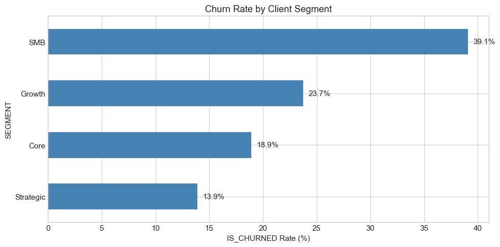

```python
# Churn rate by segment (need original SEGMENT before one-hot encoding)
# Use the base dataframe which still has SEGMENT as categorical
plot_rate_by_segment(base, 'SEGMENT', 'IS_CHURNED', title='Churn Rate by Client Segment')
plt.show()
```

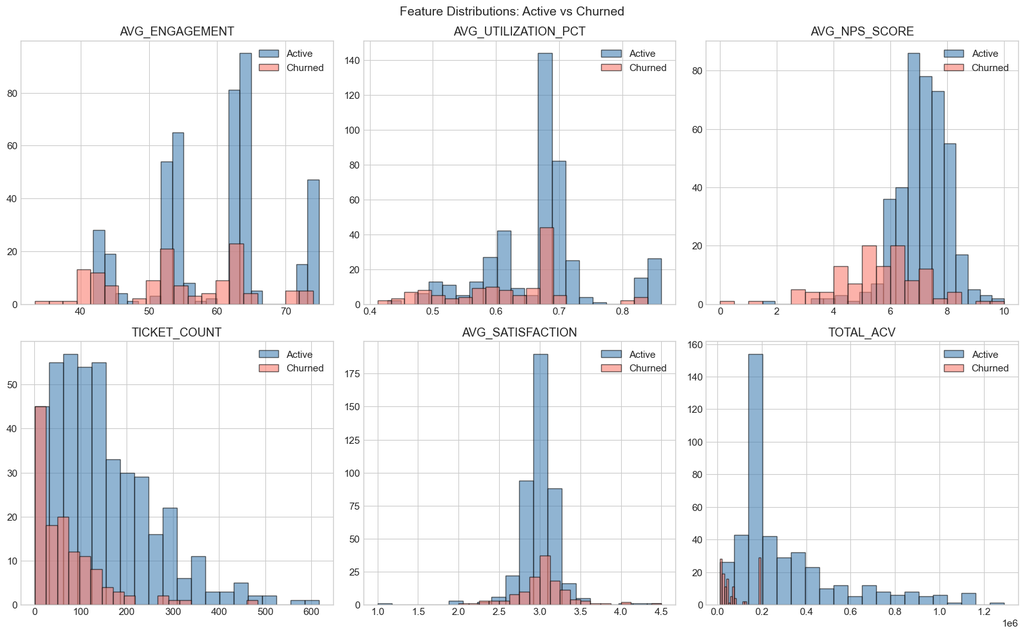

```python
# Distribution of key numeric features by churn status
fig, axes = plt.subplots(2, 3, figsize=(16, 10))
key_features = ['AVG_ENGAGEMENT', 'AVG_UTILIZATION_PCT', 'AVG_NPS_SCORE',
                'TICKET_COUNT', 'AVG_SATISFACTION', 'TOTAL_ACV']

for ax, col in zip(axes.ravel(), key_features):
    if col in features.columns:
        for label, color in [(0, 'steelblue'), (1, 'salmon')]:
            subset = features[features['IS_CHURNED'] == label][col].dropna()
            ax.hist(subset, bins=20, alpha=0.6, label=f'{"Churned" if label else "Active"}',
                    color=color, edgecolor='black')
        ax.set_title(col)
        ax.legend()

plt.suptitle('Feature Distributions: Active vs Churned', fontsize=14)
plt.tight_layout()
plt.show()
```

```
Correlation with IS_CHURNED (top 10 positive & negative):

ACTIVE_CONTRACT_COUNT             -0.830234
AVG_RESOLUTION_HRS                -0.671613
INVOICE_COUNT                     -0.441967
AVG_HOURS_USED                    -0.435261
AVG_ACV                           -0.418971
TOTAL_ACV                         -0.418971
UTIL_MONTHS                       -0.401215
LATEST_NPS                        -0.370689
NPS_SURVEY_COUNT                  -0.359651
TOTAL_INVOICED                    -0.357686
EMPLOYEE_COUNT                    -0.111359
ANNUAL_REVENUE                    -0.107068
OVERALL_ENGAGEMENT_SCORE_RECENT   -0.092349
OVERALL_ENGAGEMENT_SCORE_TREND    -0.082120
ACCOUNT_AGE_DAYS                  -0.079553
AVG_SATISFACTION                   0.061926
DAYS_SINCE_LAST_ACTIVITY           0.707078
CONTRACT_COUNT                          NaN
CANCELLED_CONTRACT_COUNT                NaN
OVERDUE_INVOICE_COUNT                   NaN
```

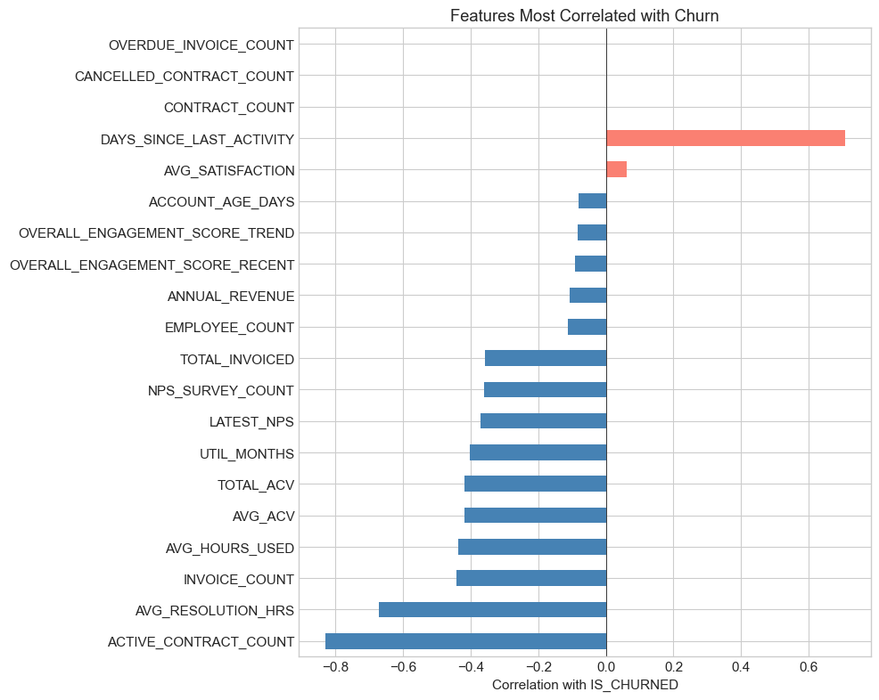

```python
# Correlation heatmap of top features
numeric_cols = features.select_dtypes(include=[np.number]).columns.tolist()
# Remove ID columns and target from correlation
corr_cols = [c for c in numeric_cols if c not in ['ACCOUNT_ID', 'INDUSTRY_ID']]

# Show correlation with IS_CHURNED specifically
target_corr = features[corr_cols].corr()['IS_CHURNED'].drop('IS_CHURNED').sort_values()
print("Correlation with IS_CHURNED (top 10 positive & negative):\n")
print(pd.concat([target_corr.head(10), target_corr.tail(10)]).to_string())

# Plot top correlated features
fig, ax = plt.subplots(figsize=(10, 8))
top_corr_features = pd.concat([target_corr.head(10), target_corr.tail(10)])
top_corr_features.plot(kind='barh', ax=ax, color=['salmon' if v > 0 else 'steelblue' for v in top_corr_features])
ax.set_xlabel('Correlation with IS_CHURNED')
ax.set_title('Features Most Correlated with Churn')
ax.axvline(0, color='black', linewidth=0.5)
plt.tight_layout()
plt.show()
```

## Step 6 — Modeling

Compare two algorithms using functions from the modeling notebook:

1. **Logistic Regression** — interpretable baseline
2. **Random Forest** — captures non-linear patterns

Both use `class_weight='balanced'` to handle any class imbalance.

```python
# --- Modeling helpers from modeling notebook ---

def prepare_classification_data(X, y, test_size=0.2, random_state=42):
    """Split data for classification (stratified by target)."""
    X_train, X_test, y_train, y_test = train_test_split(
        X, y, test_size=test_size, stratify=y, random_state=random_state
    )
    print(f'Train: {len(X_train)}, Test: {len(X_test)}')
    for label, data in [('train', y_train), ('test', y_test)]:
        dist = data.value_counts(normalize=True)
        print(f'  {label}: {dist.round(3).to_dict()}')
    return X_train, X_test, y_train, y_test

def build_pipeline(model, scale=True):
    """Wrap a model in a pipeline with optional scaling."""
    steps = []
    if scale:
        steps.append(('scaler', StandardScaler()))
    steps.append(('model', model))
    pipe = Pipeline(steps)
    print(f'Pipeline: {" -> ".join(name for name, _ in steps)}')
    return pipe

def cross_validate_classifier(model, X, y, cv=5):
    """Cross-validate a classifier (F1 score, stratified folds)."""
    splitter = StratifiedKFold(n_splits=cv, shuffle=True, random_state=42)
    scores = cross_val_score(model, X, y, cv=splitter, scoring='f1')
    print(f'CV ({cv} folds, scoring=f1):')
    print(f'  Scores: {scores.round(4)}')
    print(f'  Mean:   {scores.mean():.4f} (+/- {scores.std():.4f})')
    return scores

def tune_classifier(model, param_grid, X, y, cv=5):
    """Tune a classifier (optimizing F1)."""
    search = GridSearchCV(model, param_grid, cv=cv, scoring='f1',
                          return_train_score=True, n_jobs=-1)
    search.fit(X, y)
    results = pd.DataFrame(search.cv_results_).sort_values('rank_test_score')
    param_cols = [c for c in results.columns if c.startswith('param_')]
    display_cols = param_cols + ['mean_test_score', 'std_test_score', 'mean_train_score']
    print(f'Best params: {search.best_params_}')
    print(f'Best score:  {search.best_score_:.4f}')
    print(f'\nTop 5:')
    print(results[display_cols].head().to_string(index=False))
    return search.best_estimator_, results

def fit_and_predict(model, X_train, y_train, X_test):
    """Fit a model and generate predictions."""
    model.fit(X_train, y_train)
    predictions = model.predict(X_test)
    probabilities = None
    if hasattr(model, 'predict_proba'):
        probabilities = model.predict_proba(X_test)[:, 1]
    print(f'Predictions: {len(predictions)}')
    if probabilities is not None:
        print(f'Probability range: [{probabilities.min():.3f}, {probabilities.max():.3f}]')
    return model, predictions, probabilities
```

### 6a — Prepare Train/Test Split

```python
# Define X (features) and y (target)
# Drop non-feature columns: IDs, names, dates, status labels
drop_cols = ['ACCOUNT_ID', 'ACCOUNT_NAME', 'CREATED_DATE', 'STATUS', 'IS_CHURNED', 'INDUSTRY_ID']
feature_cols = [c for c in features.columns if c not in drop_cols]

X = features[feature_cols].copy()
y = features['IS_CHURNED'].copy()

# Safety: replace inf with NaN, then fill any remaining NaN with 0
X.replace([np.inf, -np.inf], np.nan, inplace=True)
remaining_nans = X.isnull().sum()
if remaining_nans.sum() > 0:
    print(f"Filling {remaining_nans[remaining_nans > 0].shape[0]} columns with remaining NaN/inf:")
    print(remaining_nans[remaining_nans > 0].to_string())
    X = X.fillna(0)

# Ensure all feature columns are numeric
non_numeric = list(X.select_dtypes(exclude=[np.number]).columns)
if non_numeric:
    print(f"\nDropping non-numeric columns: {non_numeric}")
    X = X.drop(columns=non_numeric)
    feature_cols = [c for c in feature_cols if c not in non_numeric]

print(f"\nFeature columns ({len(feature_cols)})")
print(f"X shape: {X.shape}, any NaN: {X.isnull().any().any()}, any inf: {np.isinf(X.values).any()}")

# Split with stratification
X_train, X_test, y_train, y_test = prepare_classification_data(X, y)
```

```
Filling 11 columns with remaining NaN/inf:
AVG_TERM_MONTHS            139
AUTO_RENEW_PCT             139
HIGH_PRIORITY_PCT            5
AVG_ENGAGEMENT               3
AVG_LOGIN_FREQ               3
AVG_FEATURE_ADOPTION         3
AVG_SUPPORT_ENGAGEMENT       3
AVG_TRAINING_COMPLETION      3
AVG_NPS_SCORE               27
NPS_RESPONSE_RATE           27
NPS_DETRACTOR_PCT           27

Dropping non-numeric columns: ['AVG_TERM_MONTHS', 'AUTO_RENEW_PCT', 'HIGH_PRIORITY_PCT', 'AVG_ENGAGEMENT', 'AVG_LOGIN_FREQ', 'AVG_FEATURE_ADOPTION', 'AVG_SUPPORT_ENGAGEMENT', 'AVG_TRAINING_COMPLETION', 'AVG_NPS_SCORE', 'NPS_RESPONSE_RATE', 'NPS_DETRACTOR_PCT', 'NEGATIVE_OUTCOME_PCT', 'POSITIVE_OUTCO…

Feature columns (29)
X shape: (558, 29), any NaN: False, any inf: False
Train: 446, Test: 112
  train: {0: 0.771, 1: 0.229}
  test: {0: 0.768, 1: 0.232}
```

### 6b — Logistic Regression

```python
# Algorithm 1: Logistic Regression (with scaling)
lr_pipe = build_pipeline(LogisticRegression(class_weight='balanced', max_iter=1000))

# Cross-validation
print("\n--- Cross-Validation ---")
lr_cv_scores = cross_validate_classifier(lr_pipe, X_train, y_train)

# Hyperparameter tuning
print("\n--- Hyperparameter Tuning ---")
lr_best, lr_tune_results = tune_classifier(
    lr_pipe,
    {'model__C': [0.001, 0.01, 0.1, 1, 10, 100]},
    X_train, y_train
)

# Final fit and predict
print("\n--- Final Predictions ---")
lr_model, lr_preds, lr_probs = fit_and_predict(lr_best, X_train, y_train, X_test)
```

```
Pipeline: scaler -> model

--- Cross-Validation ---
CV (5 folds, scoring=f1):
  Scores: [0.9302 0.9744 1.     0.9744 0.9756]
  Mean:   0.9709 (+/- 0.0226)

--- Hyperparameter Tuning ---
Best params: {'model__C': 1}
Best score:  0.9700

Top 5:
 param_model__C  mean_test_score  std_test_score  mean_train_score
           1.00         0.969958        0.025289          0.991426
           0.10         0.954972        0.031165          0.980397
          10.00         0.949230        0.045530          1.000000
         100.00         0.944120        0.046316          1.000000
           0.01         0.941245        0.019714          0.955960

--- Final Predictions ---
Predictions: 112
Probability range: [0.000, 1.000]
```

### 6c — Random Forest

```python
# Algorithm 2: Random Forest (no scaling needed for trees)
rf_pipe = build_pipeline(
    RandomForestClassifier(class_weight='balanced', random_state=42, n_jobs=-1),
    scale=False
)

# Cross-validation
print("\n--- Cross-Validation ---")
rf_cv_scores = cross_validate_classifier(rf_pipe, X_train, y_train)

# Hyperparameter tuning
print("\n--- Hyperparameter Tuning ---")
rf_best, rf_tune_results = tune_classifier(
    rf_pipe,
    {
        'model__n_estimators': [100, 200],
        'model__max_depth': [5, 10, 15, None],
        'model__min_samples_leaf': [2, 5, 10]
    },
    X_train, y_train
)

# Final fit and predict
print("\n--- Final Predictions ---")
rf_model, rf_preds, rf_probs = fit_and_predict(rf_best, X_train, y_train, X_test)
```

```
Pipeline: model

--- Cross-Validation ---
CV (5 folds, scoring=f1):
  Scores: [0.95   1.     1.     0.9756 0.9231]
  Mean:   0.9697 (+/- 0.0298)

--- Hyperparameter Tuning ---
Best params: {'model__max_depth': 5, 'model__min_samples_leaf': 10, 'model__n_estimators': 200}
Best score:  0.9663

Top 5:
param_model__max_depth  param_model__min_samples_leaf  param_model__n_estimators  mean_test_score  std_test_score  mean_train_score
                     5                             10                        200         0.966269        0.024427          0.983014
                    10                             10                        200         0.966269        0.024427          0.983014
                  None                             10                        200         0.966269        0.024427          0.983014
                    15                             10                        200         0.966269        0.024427          0.983014
                    15                              5                        200         0.965586        0.025023          0.991514

--- Final Predictions ---
Predictions: 112
Probability range: [0.000, 0.994]
```

## Step 7 — Evaluation

Metrics, confusion matrices, ROC curves, threshold analysis, feature importance, and model comparison using functions from the evaluation notebook.

```python
# --- Evaluation helpers from evaluation notebook ---

def classification_report(y_true, y_pred, y_prob=None, labels=None):
    """Print classification metrics and plot confusion matrix + ROC."""
    if labels is None:
        labels = ['Active', 'Churned']
    acc = accuracy_score(y_true, y_pred)
    prec = precision_score(y_true, y_pred)
    rec = recall_score(y_true, y_pred)
    f1 = f1_score(y_true, y_pred)
    print("Classification Metrics:")
    print(f"  Accuracy:  {acc:.4f}")
    print(f"  Precision: {prec:.4f}")
    print(f"  Recall:    {rec:.4f}")
    print(f"  F1:        {f1:.4f}")
    cm = confusion_matrix(y_true, y_pred)
    fig, ax = plt.subplots(figsize=(6, 5))
    ConfusionMatrixDisplay(cm, display_labels=labels).plot(ax=ax, cmap='Blues')
    ax.set_title('Confusion Matrix')
    plt.tight_layout()
    plt.show()
    if y_prob is not None:
        fpr, tpr, _ = roc_curve(y_true, y_prob)
        roc_auc = auc(fpr, tpr)
        fig, ax = plt.subplots(figsize=(6, 5))
        ax.plot(fpr, tpr, label=f'AUC = {roc_auc:.3f}')
        ax.plot([0, 1], [0, 1], 'k--', alpha=0.5)
        ax.set_xlabel('False Positive Rate')
        ax.set_ylabel('True Positive Rate')
        ax.set_title('ROC Curve')
        ax.legend()
        plt.tight_layout()
        plt.show()
    return {'accuracy': acc, 'precision': prec, 'recall': rec, 'f1': f1, 'confusion_matrix': cm}

def threshold_analysis(y_true, y_prob, thresholds=None):
    """Evaluate classification at multiple probability thresholds."""
    if thresholds is None:
        thresholds = np.arange(0.1, 0.9, 0.05)
    rows = []
    for t in thresholds:
        y_pred = (y_prob >= t).astype(int)
        rows.append({
            'threshold': t,
            'predicted_positive': int(y_pred.sum()),
            'precision': precision_score(y_true, y_pred, zero_division=0),
            'recall': recall_score(y_true, y_pred),
            'f1': f1_score(y_true, y_pred, zero_division=0)
        })
    results = pd.DataFrame(rows)
    fig, ax = plt.subplots(figsize=(10, 5))
    ax.plot(results['threshold'], results['precision'], label='Precision')
    ax.plot(results['threshold'], results['recall'], label='Recall')
    ax.plot(results['threshold'], results['f1'], label='F1', linestyle='--')
    ax.axvline(0.5, color='gray', linestyle=':', alpha=0.5, label='Default (0.5)')
    ax.set_xlabel('Threshold')
    ax.set_ylabel('Score')
    ax.set_title('Precision-Recall Trade-off by Threshold')
    ax.legend()
    plt.tight_layout()
    plt.show()
    return results

def plot_feature_importance(model, feature_names, top_n=15):
    """Plot feature importance for tree-based or linear models."""
    if hasattr(model, 'feature_importances_'):
        importances = model.feature_importances_
        title = 'Feature Importance'
    elif hasattr(model, 'coef_'):
        importances = np.abs(model.coef_).flatten()
        title = 'Feature Importance (|coefficient|)'
    else:
        # Try to get from pipeline
        est = model.steps[-1][1] if hasattr(model, 'steps') else model
        if hasattr(est, 'feature_importances_'):
            importances = est.feature_importances_
            title = 'Feature Importance'
        elif hasattr(est, 'coef_'):
            importances = np.abs(est.coef_).flatten()
            title = 'Feature Importance (|coefficient|)'
        else:
            print("Model does not have feature_importances_ or coef_")
            return None
    imp_df = pd.DataFrame({'feature': feature_names, 'importance': importances})
    imp_df = imp_df.sort_values('importance', ascending=False)
    top = imp_df.head(top_n)
    fig, ax = plt.subplots(figsize=(10, max(4, top_n * 0.35)))
    ax.barh(range(len(top)), top['importance'].values)
    ax.set_yticks(range(len(top)))
    ax.set_yticklabels(top['feature'])
    ax.invert_yaxis()
    ax.set_xlabel('Importance')
    ax.set_title(title)
    plt.tight_layout()
    plt.show()
    return imp_df

def compare_models(results_dict, task='classification'):
    """Side-by-side comparison of multiple models."""
    clean = {}
    for name, metrics in results_dict.items():
        clean[name] = {k: v for k, v in metrics.items() if isinstance(v, (int, float))}
    df = pd.DataFrame(clean).T
    if task == 'classification':
        cols = ['accuracy', 'precision', 'recall', 'f1']
        sort_col = 'f1'
    else:
        cols = ['rmse', 'mae', 'r2', 'mape']
        sort_col = 'r2'
    available = [c for c in cols if c in df.columns]
    df = df[available].sort_values(sort_col, ascending=False)
    print(df.round(4).to_string())
    fig, ax = plt.subplots(figsize=(10, max(3, len(df) * 0.6)))
    df[sort_col].plot(kind='barh', ax=ax)
    ax.set_xlabel(sort_col.upper())
    ax.set_title(f'Model Comparison ({sort_col.upper()})')
    plt.tight_layout()
    plt.show()
    return df
```

### 7a — Logistic Regression Evaluation

```
==================================================
LOGISTIC REGRESSION
==================================================
Classification Metrics:
  Accuracy:  0.9732
  Precision: 0.9259
  Recall:    0.9615
  F1:        0.9434
```

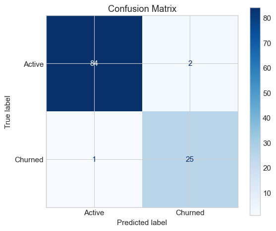

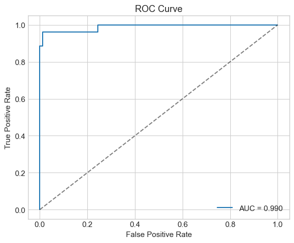

```python
# Evaluate Logistic Regression
print("=" * 50)
print("LOGISTIC REGRESSION")
print("=" * 50)
lr_results = classification_report(y_test, lr_preds, y_prob=lr_probs)
```

```
Logistic Regression — Feature Importance
```

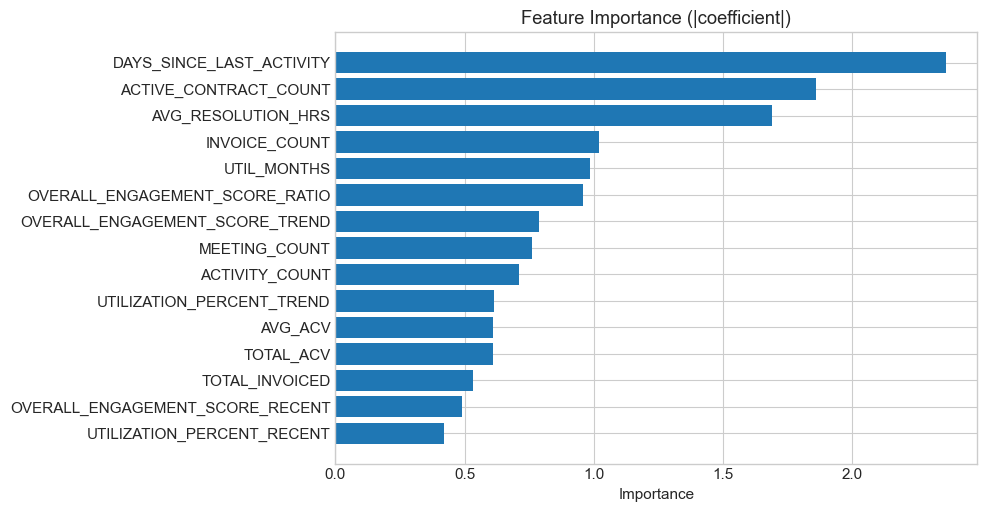

```python
# Feature importance for Logistic Regression
print("Logistic Regression — Feature Importance")
lr_importance = plot_feature_importance(lr_model, feature_cols, top_n=15)
```

### 7b — Random Forest Evaluation

```
==================================================
RANDOM FOREST
==================================================
Classification Metrics:
  Accuracy:  0.9732
  Precision: 0.9259
  Recall:    0.9615
  F1:        0.9434
```

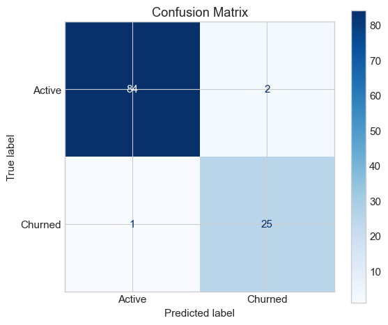

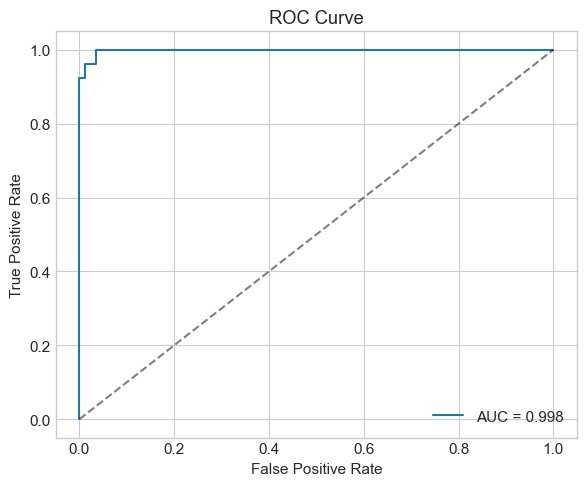

```python
# Evaluate Random Forest
print("=" * 50)
print("RANDOM FOREST")
print("=" * 50)
rf_results = classification_report(y_test, rf_preds, y_prob=rf_probs)
```

```
Random Forest — Feature Importance
```

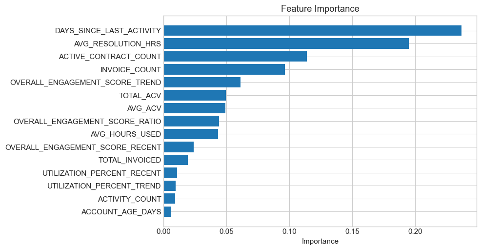

```python
# Feature importance for Random Forest
print("Random Forest — Feature Importance")
rf_importance = plot_feature_importance(rf_model, feature_cols, top_n=15)
```

### 7c — Model Comparison & Threshold Analysis

```
==================================================
MODEL COMPARISON
==================================================
                     accuracy  precision  recall      f1
Logistic Regression    0.9732     0.9259  0.9615  0.9434
Random Forest          0.9732     0.9259  0.9615  0.9434
```

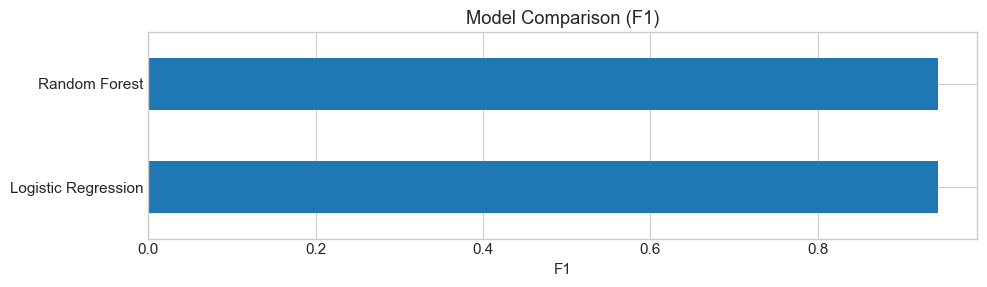

```python
# Side-by-side model comparison
print("=" * 50)
print("MODEL COMPARISON")
print("=" * 50)
comparison = compare_models({
    'Logistic Regression': lr_results,
    'Random Forest': rf_results
}, task='classification')
```

```
Best model: Logistic Regression

Threshold analysis — find the best trade-off for outreach:
```

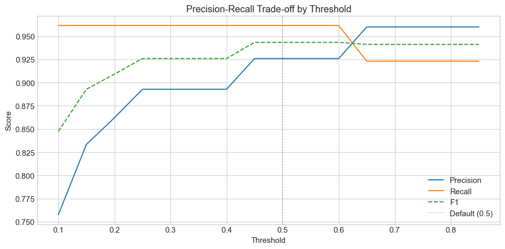

|  | threshold | predicted_positive | precision | recall | f1 |
| --- | --- | --- | --- | --- | --- |
| 0 | 0.10 | 33 | 0.758 | 0.962 | 0.847 |
| 1 | 0.15 | 30 | 0.833 | 0.962 | 0.893 |
| 2 | 0.20 | 29 | 0.862 | 0.962 | 0.909 |
| 3 | 0.25 | 28 | 0.893 | 0.962 | 0.926 |
| 4 | 0.30 | 28 | 0.893 | 0.962 | 0.926 |
| 5 | 0.35 | 28 | 0.893 | 0.962 | 0.926 |
| 6 | 0.40 | 28 | 0.893 | 0.962 | 0.926 |
| 7 | 0.45 | 27 | 0.926 | 0.962 | 0.943 |
| 8 | 0.50 | 27 | 0.926 | 0.962 | 0.943 |
| 9 | 0.55 | 27 | 0.926 | 0.962 | 0.943 |
| 10 | 0.60 | 27 | 0.926 | 0.962 | 0.943 |
| 11 | 0.65 | 25 | 0.960 | 0.923 | 0.941 |
| 12 | 0.70 | 25 | 0.960 | 0.923 | 0.941 |
| 13 | 0.75 | 25 | 0.960 | 0.923 | 0.941 |
| 14 | 0.80 | 25 | 0.960 | 0.923 | 0.941 |
| 15 | 0.85 | 25 | 0.960 | 0.923 | 0.941 |

```python
# Threshold analysis on the best model's probabilities
# Use whichever model had better F1
best_model_name = comparison.index[0]  # sorted by F1 descending
if best_model_name == 'Logistic Regression':
    best_probs = lr_probs
    best_model = lr_model
    best_preds = lr_preds
else:
    best_probs = rf_probs
    best_model = rf_model
    best_preds = rf_preds

print(f"\nBest model: {best_model_name}")
print("\nThreshold analysis — find the best trade-off for outreach:")
threshold_results = threshold_analysis(y_test, best_probs)
threshold_results.round(3)
```

## Step 8 — Prioritized Risk List

Score all **active** accounts with the best model and produce a ranked list for Nate Kowalski's outreach team.

```python
# Score ALL active accounts (not just test set) using the best model
# Re-fit on ALL labeled data for maximum predictive power
best_model.fit(X, y)

# Get active accounts from the feature matrix (case-insensitive)
active_mask = features['STATUS'].str.lower() == 'active'
X_active = features.loc[active_mask, feature_cols].copy()
active_accounts = features.loc[active_mask, ['ACCOUNT_ID', 'ACCOUNT_NAME']].copy()

# Predict churn probabilities
if hasattr(best_model, 'predict_proba'):
    active_accounts['CHURN_PROBABILITY'] = best_model.predict_proba(X_active)[:, 1]
else:
    active_accounts['CHURN_PROBABILITY'] = best_model.predict(X_active)

# Add segment info (from original accounts table before encoding)
segment_map = accounts.set_index('ACCOUNT_ID')['SEGMENT'].to_dict()
active_accounts['SEGMENT'] = active_accounts['ACCOUNT_ID'].map(segment_map)

# Assign risk tiers
active_accounts['RISK_TIER'] = pd.cut(
    active_accounts['CHURN_PROBABILITY'],
    bins=[0, 0.3, 0.6, 1.0],
    labels=['Low', 'Medium', 'High']
)

# Sort by churn probability descending
risk_list = active_accounts.sort_values('CHURN_PROBABILITY', ascending=False)

print(f"Scored {len(risk_list)} active accounts\n")
print("Risk tier breakdown:")
print(risk_list['RISK_TIER'].value_counts().to_string())
print(f"\n{'='*60}")
print("TOP 20 HIGH-RISK ACCOUNTS FOR OUTREACH")
print(f"{'='*60}")
risk_list.head(20)
```

```
Scored 430 active accounts

Risk tier breakdown:
RISK_TIER
Low       421
Medium      8
High        1

============================================================
TOP 20 HIGH-RISK ACCOUNTS FOR OUTREACH
============================================================
```

|  | ACCOUNT_ID | ACCOUNT_NAME | CHURN_PROBABILITY | SEGMENT | RISK_TIER |
| --- | --- | --- | --- | --- | --- |
| 173 | 248 | Young Group Inc. | 0.863828 | SMB | High |
| 72 | 107 | Denver Distribution Inc. | 0.524642 | SMB | Medium |
| 211 | 295 | Precision Columbus Ltd. | 0.422064 | Growth | Medium |
| 514 | 737 | Minneapolis Packaging Corp. | 0.417205 | Core | Medium |
| 40 | 66 | Quality Minneapolis | 0.390795 | Growth | Medium |
| 403 | 575 | Minneapolis Parts LLC | 0.321052 | Core | Medium |
| 67 | 101 | Indianapolis Products Inc. | 0.308335 | SMB | Medium |
| 244 | 344 | Taylor Materials Corp. | 0.306950 | SMB | Medium |
| 547 | 784 | National Materials LLC | 0.305208 | Growth | Medium |
| 472 | 682 | United Materials Corp. | 0.294745 | SMB | Low |
| 542 | 778 | Anderson Technologies Co. | 0.237526 | Growth | Low |
| 501 | 720 | Central Logistics | 0.232783 | Core | Low |
| 478 | 689 | Morrison Services | 0.229663 | Core | Low |
| 112 | 159 | Advanced Distribution LLC | 0.227132 | Growth | Low |
| 143 | 203 | Strategic Chicago Inc. | 0.217708 | Growth | Low |
| 189 | 265 | American Pittsburgh | 0.215127 | Growth | Low |
| 14 | 21 | Modern Houston Inc. | 0.213931 | Growth | Low |
| 529 | 757 | Atlantic Services Ltd. | 0.202157 | Core | Low |
| 214 | 299 | Quality Charlotte Corp. | 0.173464 | Core | Low |
| 420 | 600 | Anderson Group Corp. | 0.168663 | Growth | Low |

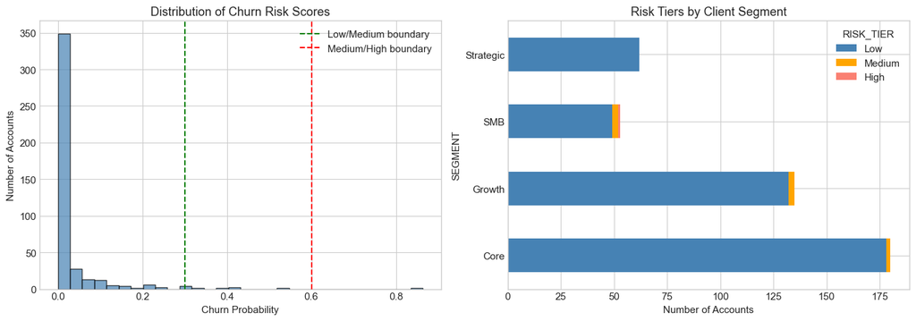

```python
# Visualize risk distribution
fig, axes = plt.subplots(1, 2, figsize=(14, 5))

# Histogram of churn probabilities
axes[0].hist(risk_list['CHURN_PROBABILITY'], bins=30, edgecolor='black', alpha=0.7, color='steelblue')
axes[0].axvline(0.3, color='green', linestyle='--', label='Low/Medium boundary')
axes[0].axvline(0.6, color='red', linestyle='--', label='Medium/High boundary')
axes[0].set_xlabel('Churn Probability')
axes[0].set_ylabel('Number of Accounts')
axes[0].set_title('Distribution of Churn Risk Scores')
axes[0].legend()

# Risk tier counts by segment
risk_by_segment = risk_list.groupby(['SEGMENT', 'RISK_TIER']).size().unstack(fill_value=0)
risk_by_segment.plot(kind='barh', stacked=True, ax=axes[1],
                     color=['steelblue', 'orange', 'salmon'])
axes[1].set_xlabel('Number of Accounts')
axes[1].set_title('Risk Tiers by Client Segment')

plt.tight_layout()
plt.show()
```

```python
# Export the full prioritized risk list to CSV
risk_list.to_csv('churn_risk_list.csv', index=False)
print(f"Exported {len(risk_list)} accounts to churn_risk_list.csv")
```

```
Exported 430 accounts to churn_risk_list.csv
```

## Cleanup

```python
conn.close()
print("Connection closed.")
```

```
Connection closed.
```